# prob3cp2

Matheus Freitas

4 de julho de 2018

Nesta analise, usaremos dados das unidades acadêmicas da UFCG para analisar os seus tipos de funcinários.

# Qual seria um bom valor para K?

Para agruparmos os dados para melhor analisa-los é importante decidir a quantidade de grupos em que dividiremos os dados, ou seja, K. Para fazer essa decisão de forma automática iremos usar o algoritmo “Between/totss”.

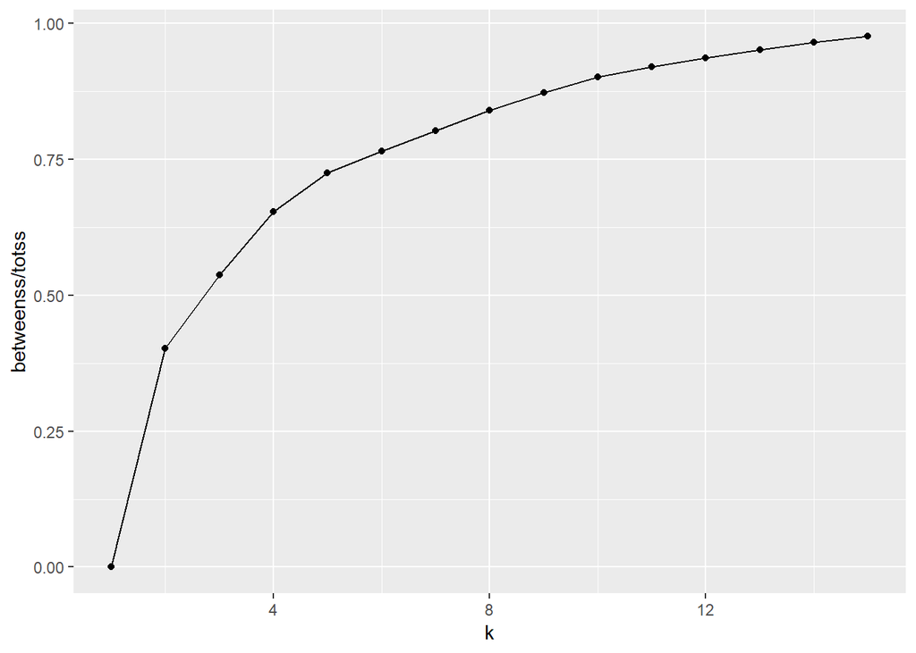

```r
set.seed(30)


explorando_k = tibble(k = 1:15) %>%
  group_by(k) %>%
  do(kmeans(NaRV.omit(select(ufcg_scaled, -UORG_LOTACAO)),
           centers = .$k,
           nstart = 20) %>%
      glance())

explorando_k %>%
  ggplot(aes(x = k, y = betweenss / totss)) +
  geom_line() +
  geom_point()
```

Observando este gráfico, fica perceptível que a partir de k igual 4, já não temos uma diferença muito grande. O que queremos é justamente o ponto no anterior ao ponto do qual o gráfico fica mais “linear”. Dessa maneira, o nosso K escolhido será 4.

# K-means

Aqui aplicaremos o algoritmo k-means para agrupar os dados em 4 clusters distintos.

```r
set.seed(30)

n_clusters = 4

km = ufcg_uas %>%
  select(-UORG_LOTACAO) %>%
  kmeans(centers = n_clusters, nstart = 20)

uas_agrupadas = km %>%
  augment(ufcg_scaled) %>%
  gather(key = "variável",
         value = "valor",
         -UORG_LOTACAO,
         -.cluster)


p = ggplot(uas_agrupadas, aes(x=`variável`,
             y=valor,
             text = paste("Unidade Acadêmica:",UORG_LOTACAO),
             group = UORG_LOTACAO,
             colour = .cluster)) +
  labs(title = "Clusters")+
  theme(legend.position= "none") +
  geom_point() +
  coord_flip() +
  facet_wrap(~ .cluster)


ggplotly(p, tooltip = "text")
```

[interactive chart not shown]

Os grupos podem ser classificados da seguinte maneira:

**Grupo 1:** Neste grupo fica claro a presença de unidades acadêmicas com a menor quantidade de professores, em qualquer tipo de regime, e também funcinários.

**Grupo 2:** Grupo que mais possui unidades acadêmicas com muitos professores em regime de 40h ou dedicação exclusiva.

**Grupo 3:** Possui apenas duas unidades acadêmicas, medicina e ciências da vida. Ambas são as únicas que possuem professores de 20h muito próximo a 4.

**Grupo 4:** Este grupo possui apenas uma única unidade acadêmica com professores em regime de 20h e vários professores em regime de 40h ou dedicação exclusiva.